# Chapter 11: Time series analysis

Runnable workbook for Regression with R and Python

This runnable workbook supplements the reference workbook. It adds setup code and lightweight fixes so the chapter can usually be rendered and run end-to-end.

- Runnable companion script: R/chapter11.R
- Reference workbook: chapter11_workbook.Rmd
- Textbook chapter: `Time series analysis`
- Package installation lines are shown as comments and are not run automatically during rendering.

## Time series analysis with R

### Box 01

Textbook context: Section: Autoregressive regression | Subsection: Deterministic or stochastic trend? | Subsubsection: Stochastic Trend.

```r
    df <- read.csv(file.path("data", "time_series_sweden.csv"))
```

### Box 02

Textbook context: Section: Autoregressive regression | Subsection: Deterministic or stochastic trend? | Subsubsection: Stochastic Trend.

```r
    gdp_ts <- ts(df$gdp, frequency = 4, start = c(1981, 1))
```

### Box 03

Textbook context: Section: Autoregressive regression | Subsection: Deterministic or stochastic trend? | Subsubsection: Stochastic Trend.

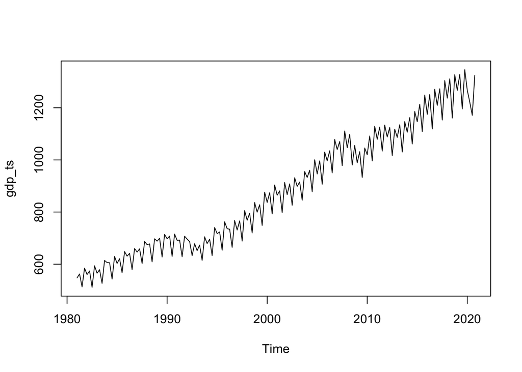

```r
    plot(gdp_ts)
```

### Box 04

Textbook context: Section: Autoregressive regression | Subsection: Deterministic or stochastic trend? | Subsubsection: Stochastic Trend.

```r
    gdpL1 <- lag(gdp_ts, k=-1)
    gdpL2 <- lag(gdp_ts, k=-2)
    gdpF1 <- lag(gdp_ts, k=1)
    gdpF2 <- lag(gdp_ts, k=2)
```

### Box 05

Textbook context: Section: Autoregressive regression | Subsection: Deterministic or stochastic trend? | Subsubsection: Stochastic Trend.

```r
    ma <- (gdpL2/2 + gdpL1 + gdp_ts +  gdpF1 + gdpF2/2)/4
```

### Box 06

Textbook context: Section: Autoregressive regression | Subsection: Deterministic or stochastic trend? | Subsubsection: Stochastic Trend.

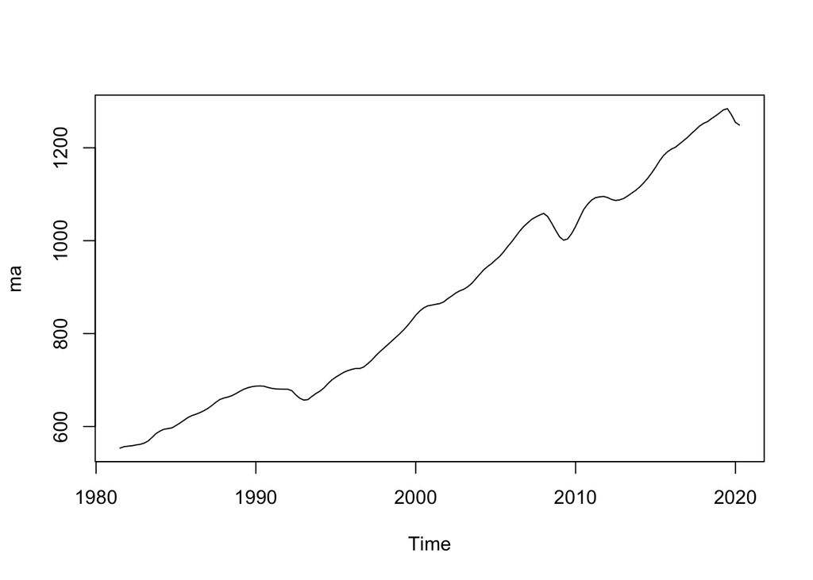

```r
    plot(ma)
```

### Box 07

Textbook context: Section: Autoregressive regression | Subsection: Deterministic or stochastic trend? | Subsubsection: Stochastic Trend.

```r
    mean_gdp <- mean(gdp_ts)
    r_1 <- (sum((gdp_ts - mean_gdp) * (gdpL1 - mean_gdp))) /
           sum((gdp_ts - mean_gdp)^2)
```

### Box 08

Textbook context: Section: Autoregressive regression | Subsection: Deterministic or stochastic trend? | Subsubsection: Stochastic Trend.

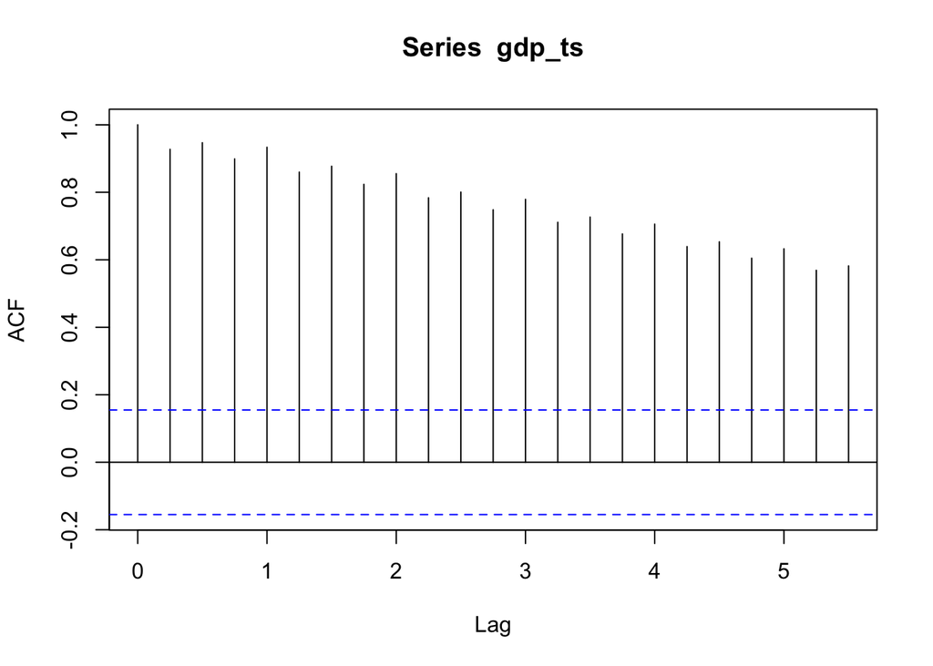

```r
 autocorrelation_function <- acf(gdp_ts)
```

### Box 09

Textbook context: Section: Autoregressive regression | Subsection: Deterministic or stochastic trend? | Subsubsection: Stochastic Trend.

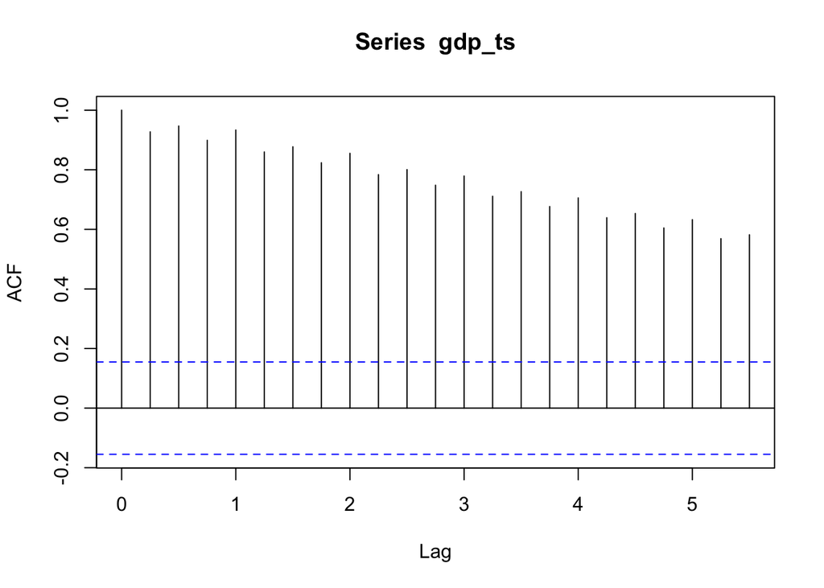

```r
    plot(autocorrelation_function)
```

### Box 10

Textbook context: Section: Autoregressive regression | Subsection: Deterministic or stochastic trend? | Subsubsection: Stochastic Trend.

```r
    dloggdp <- (log(gdp_ts) - log(gdpL1)) * 100
    maL1 <- lag(ma, k=-1)
    dlogma <- (log(ma) - log(maL1)) * 100
```

### Box 11

Textbook context: Section: Autoregressive regression | Subsection: Deterministic or stochastic trend? | Subsubsection: Stochastic Trend.

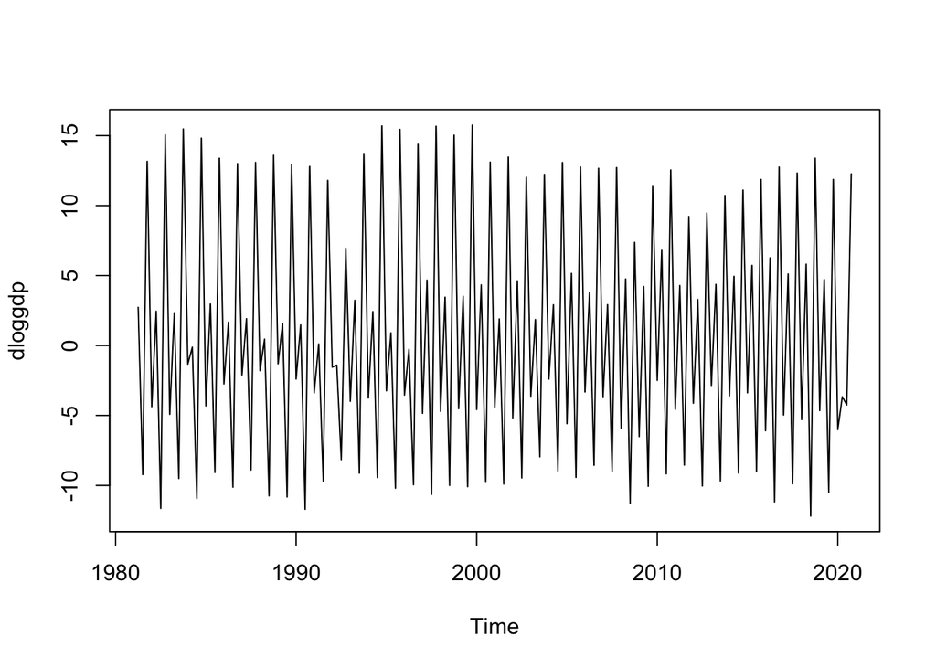

```r
plot(dloggdp)
```

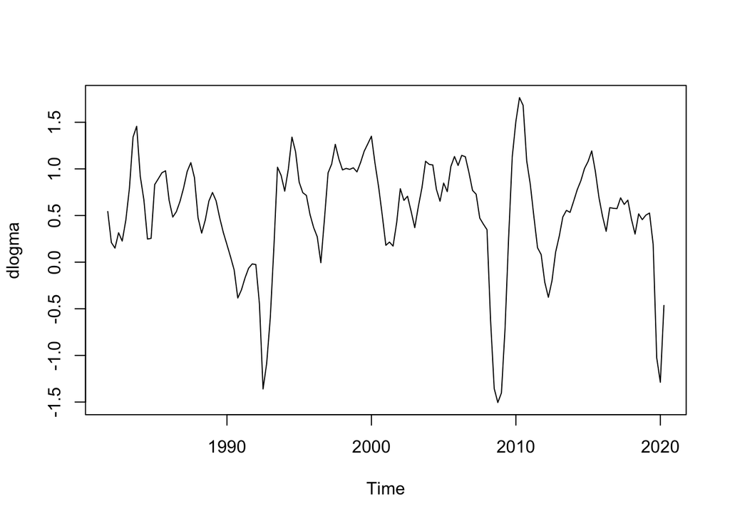

```r
plot(dlogma)
```

### Box 12

Textbook context: Section: Autoregressive regression | Subsection: Deterministic or stochastic trend? | Subsubsection: Stochastic Trend.

```r
 dloggdpL1 <- lag(dloggdp, k=-1)
 dlogmaL1 <- lag(dlogma, k=-1)
```

### Box 13

Textbook context: Section: Autoregressive regression | Subsection: Deterministic or stochastic trend? | Subsubsection: Stochastic Trend.

```r
    mv_ts <- ts.union(gdp_ts, gdpL1, gdpL2, gdpF1, gdpF2,
                      ma, dloggdp, dlogma, dloggdpL1,
                      dlogmaL1)
    dft <- data.frame(mv_ts)
```

### Box 14

Textbook context: Section: Autoregressive regression | Subsection: Deterministic or stochastic trend? | Subsubsection: Stochastic Trend.

```r
 ar1_model <- lm(dloggdp ~ dloggdpL1, data=dft)
 summary(ar1_model)
```

```
#>
#> Call:
#> lm(formula = dloggdp ~ dloggdpL1, data = dft)
#>
#> Residuals:
#>      Min       1Q   Median       3Q      Max
#> -11.9274  -5.4736   0.9935   4.9195   9.3643
#>
#> Coefficients:
#>             Estimate Std. Error t value Pr(>|t|)
#> (Intercept)  0.90267    0.45918   1.966   0.0511 .
#> dloggdpL1   -0.74932    0.05372 -13.950   <2e-16 ***
#> ---
#> Signif. codes:  0 '***' 0.001 '**' 0.01 '*' 0.05 '.' 0.1 ' ' 1
#>
#> Residual standard error: 5.763 on 156 degrees of freedom
#>   (6 observations deleted due to missingness)
#> Multiple R-squared:  0.555,  Adjusted R-squared:  0.5522
#> F-statistic: 194.6 on 1 and 156 DF,  p-value: < 2.2e-16
```

### Box 15

Textbook context: Section: Autoregressive regression | Subsection: Deterministic or stochastic trend? | Subsubsection: Stochastic Trend.

```r
 library (sandwich)
 cov_matrix <- NeweyWest(ar1_model, lag=5, prewhite=FALSE)
```

### Box 16

Textbook context: Section: Autoregressive regression | Subsection: Deterministic or stochastic trend? | Subsubsection: Stochastic Trend.

```r
    std_errors <- sqrt(diag(cov_matrix))
```

### Box 17

Textbook context: Section: Autoregressive regression | Subsection: Deterministic or stochastic trend? | Subsubsection: Stochastic Trend.

```r
 ar1_model_alt <- ar.ols(dloggdp,
 order.max = 1,
 aic=FALSE,
 demean = FALSE,
 intercept = TRUE)
```

### Box 18

Textbook context: Section: Autoregressive regression | Subsection: Deterministic or stochastic trend? | Subsubsection: Stochastic Trend.

```r
    ar5_model <- ar.ols(dloggdp,
      order.max = 5,
      aic=TRUE,
      demean = FALSE,
      intercept = TRUE)
```